# Graficar en R

R tiene una inmensa capacidad de graficar y visualizar datos de todo tipo, incluídos datos genéticos.

Las gráficas pueden hacerse desde la base de R (`base`) o con paquetes especializados en graficar, como `lattice`, o más recientemente `ggplot2` y `ggbio`. También paquetes especializados en un tipo de datos que incluyen funciones para graficar, como `ape` para árboles filogenéticos.

En esta sección veremos una introducción a graficar en R usando `graphics` que es el sistema que viene con `base` y luego nos enfocaremos en gráficas más complejas y las principales usadas en análisis genéticos. En R se puede hacer mucho más que lo que veremos aquí, recomiendo profundizar.

**Una de las mejores formas de aprender a hacer gráficas en R es buscar en internet/libro una gráfica parecida a la que queremos hacer y ver el código**. Algunas recomendaciones:

- Sección IV de Adler, J. (2012) *R in a Nutshell* O’Reilly.
- [R Graph Gallery](http://www.r-graph-gallery.com/)
- [R Graphics Cookbook](http://www.cookbook-r.com/Graphs/)
- [Blog de phytools](http://blog.phytools.org/)
- [Making maps with R en The Molecular Ecologist](http://www.molecularecologist.com/2012/09/making-maps-with-r/)
- [Documentación online de ggplot2](http://docs.ggplot2.org/current/)
- [Documentación online de ggbio](http://www.tengfei.name/ggbio/docs/)

## Base Graphics

Estas son las principales funciones para graficar utilizando la base de R. Puedes buscar ayuda de cada una con su nombre, y además en explorar argumentos extras con `?par`

- `plot`: generic x-y plotting
- `barplot`: bar plots
- `boxplot`: box-and-whisker plot
- `hist`: histograms
- `pie`: pie charts
- `dotchart`: cleveland dot plots
- `image`, `heatmap`, `contour`, `persp`: functions to generate image-like plots
- `qqnorm`, `qqline`, `qqplot`: distribution comparison plots

Veremos algunos ejemplos y luego cambiaremos al paquete `ggplot2`

### Gráficas x,y:

Dando x, y:

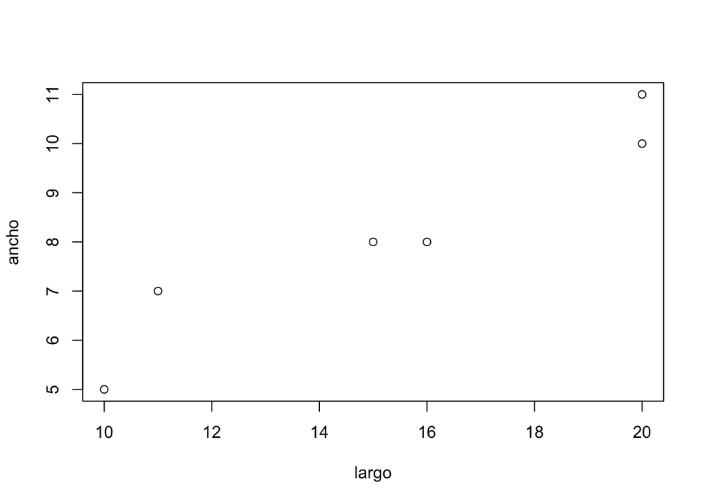

```r
largo<-c(10,20,11,15,16,20)
ancho<-c(5,10,7,8,8,11)
plot(x=largo, y=ancho)
```

Dando un objeto que tiene dos columnas, se toman automático como x,y:

```r
# ver el contenido de `cars`(una df ejemplo que viene con R)
head(cars)
```

```
##   speed dist
## 1     4    2
## 2     4   10
## 3     7    4
## 4     7   22
## 5     8   16
## 6     9   10
```